# Project Python Foundations: FoodHub Data Analysis

### **Question 7**: Which are the top 5 restaurants in terms of the number of orders received? [1 mark]

```python
restaurant_counts_sorted = data['restaurant_name'].value_counts(ascending=False)
# Count occurrences of each restaurant and then sort them in descending order

restaurant_counts_sorted.head()
# Display the top 5 restaurants
```

```
restaurant_name
Shake Shack                  219
The Meatball Shop            132
Blue Ribbon Sushi            119
Blue Ribbon Fried Chicken     96
Parm                          68
Name: count, dtype: int64
```

```python
data['restaurant_name'].nunique()
# I wanted to see how many restaurants were ordered from
```

```
178
```

#### Observations:

- I wonder if Blue Ribbon Sushi and Blue Ribbon Fried Chicken are related. It's possible, if they are the same restaurant, that they should be grouped together for data analysis (or maybe not).
- It's odd to me that Shake Shack has over 10% of all deliveries even though there are 178 different restaurants represented. My best guess is that either Shake Shack is running some kind of promotion, or they have excellent prep/delivery times.

### **Question 8**: Which is the most popular cuisine on weekends? [1 mark]

```python
weekend_data = data[data['day_of_the_week'] == 'Weekend']
# This creates a data frame that only includes weekend values

sorted_weekend_data = weekend_data['cuisine_type'].value_counts(ascending=False)
# This sorts the data by its popularity

sorted_weekend_data.head()
```

```
cuisine_type
American    415
Japanese    335
Italian     207
Chinese     163
Mexican      53
Name: count, dtype: int64
```

#### Observations:

- We can see American is the most popular cuisine_type.
- The sorted_weekend_data data frame is also useful because we can see all of the cuisine types ordered by popularity. It might be interesting to see the least popular cuisine type as well.

### **Question 9**: What percentage of the orders cost more than 20 dollars? [2 marks]

```python
x=(data['cost_of_the_order']>20).sum() # how many entries cost more than 20
print(f'The total number of orders over $20 is {x}.')
y=(x/1898)*100 # express this as a percent by dividing by the total number of deliveries and multiplying by 100
z='{:.1f}'.format(y) # I only want 1 place value after the decimal
print(f'The percentage of deliveries that cost more than $20 is {z}%.')
```

```
The total number of orders over $20 is 555.
The percentage of deliveries that cost more than $20 is 29.2%.
```

#### Observations:

- This means that over 70% of orders come in under $20. If the company wants customers to spend more, they might need incentivize orders over twenty dollars. Though it may be that the orders have to be small if they're mostly delivered by bike riders.

### **Question 10**: What is the mean order delivery time? [1 mark]

```python
data.describe().T # there are many ways to get this information but this seemed the fastest.
```

|  | count | mean | std | min | 25% | 50% | 75% | max |
| --- | --- | --- | --- | --- | --- | --- | --- | --- |
| order_id | 1898.0 | 1.477496e+06 | 548.049724 | 1476547.00 | 1477021.25 | 1477495.50 | 1.477970e+06 | 1478444.00 |
| customer_id | 1898.0 | 1.711685e+05 | 113698.139743 | 1311.00 | 77787.75 | 128600.00 | 2.705250e+05 | 405334.00 |
| cost_of_the_order | 1898.0 | 1.649885e+01 | 7.483812 | 4.47 | 12.08 | 14.14 | 2.229750e+01 | 35.41 |
| rating | 1162.0 | 4.344234e+00 | 0.741478 | 3.00 | 4.00 | 5.00 | 5.000000e+00 | 5.00 |
| food_preparation_time | 1898.0 | 2.737197e+01 | 4.632481 | 20.00 | 23.00 | 27.00 | 3.100000e+01 | 35.00 |
| delivery_time | 1898.0 | 2.416175e+01 | 4.972637 | 15.00 | 20.00 | 25.00 | 2.800000e+01 | 33.00 |

#### Observations:

- The mean delivery time is 24.2 minutes.

### **Question 11:** The company has decided to give 20% discount vouchers to the top 3 most frequent customers. Find the IDs of these customers and the number of orders they placed. [1 mark]

```python
customers_by_orders = data['customer_id'].value_counts(ascending=False)
# this will give us a new data frame sorted by which customer ids appear the most

customers_by_orders.head(3)
# Display the top 5 restaurants
```

```
customer_id
52832    13
47440    10
83287     9
Name: count, dtype: int64
```

#### Observations:

- Customers with the ids 52832, 47440, and 83287 ordered the most food.

### **Question 12**: Perform a multivariate analysis to explore relationships between the important variables in the dataset. (It is a good idea to explore relations between numerical variables as well as relations between numerical and categorical variables) [10 marks]

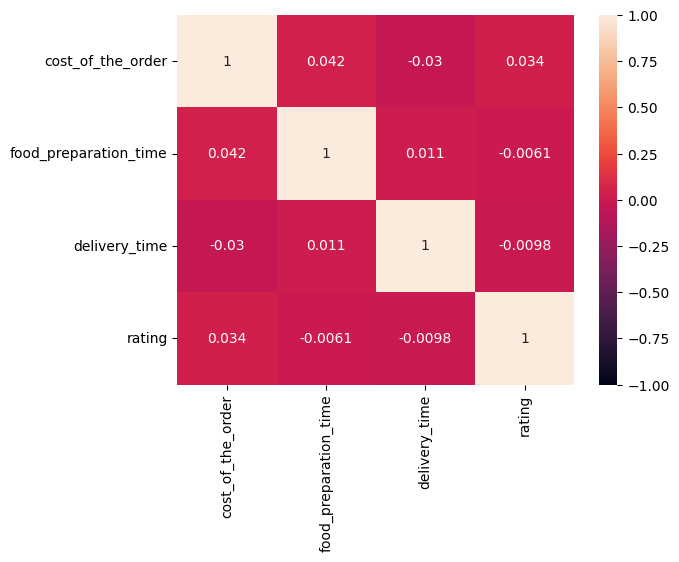

```python
numeric_data=['cost_of_the_order','food_preparation_time','delivery_time', 'rating']
numeric_df=data[numeric_data]
sns.heatmap(numeric_df.corr(), annot=True, vmin=-1, vmax=1)
plt.show()
```

- There seems to be no correlation, positive or negative between delivery time, prep time, cost, and rating. This seems unusual. We would expect to see better ratings for faster orders and worse ratings for slower orders.

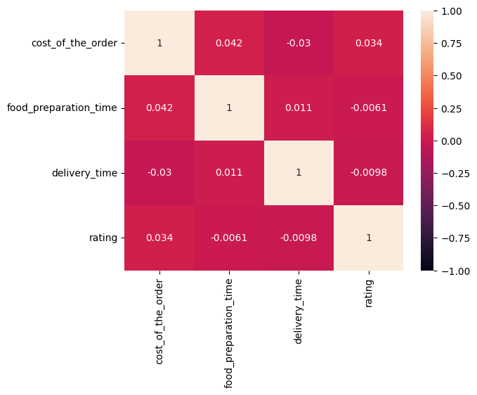

```python
# I want to try creating a column that adds the food prep time and delivery time to see if the total wait time correlates with anything
data['total_wait']=data['food_preparation_time']+data['delivery_time'] #adds the category to original data
numeric_data.append('total_wait') #adds this new category to the list that indexes the numeric_df data frame
sns.heatmap(numeric_df.corr(), annot=True, vmin=-1, vmax=1)
plt.show()
```

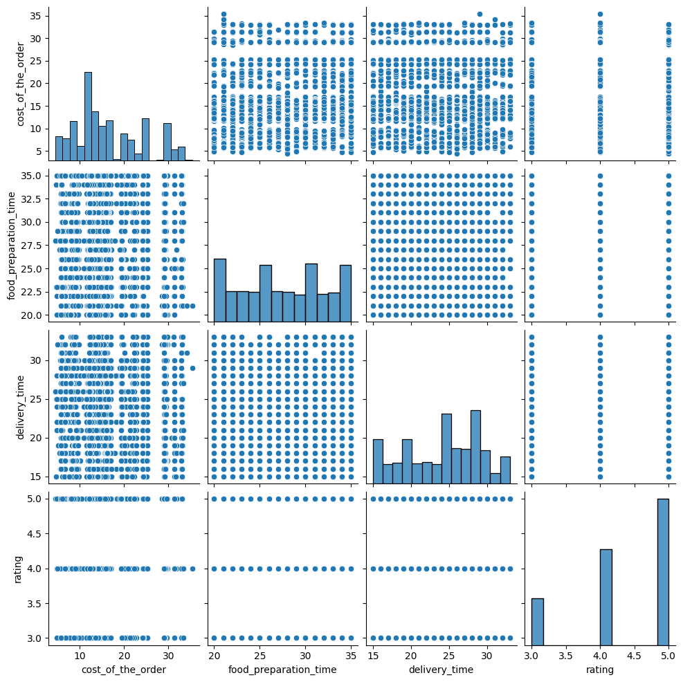

```python
# let's visualize this data in another way
sns.pairplot(data=numeric_df)
plt.show()
```

- It seems that there is no information to be learned from the numeric parts of this data set. Ordinarily we would assume that something would correlate with ratings but this doesn't seem to be the case

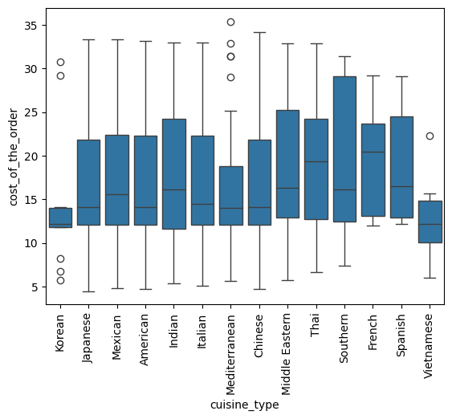

```python
# Next we'll compare catagorical data with numeric data
sns.boxplot(data=data, x='cuisine_type', y='cost_of_the_order')
plt.xticks(rotation=90)
plt.show()
```

- We can see that customers spend less on average for Korean, Mediterranean, and Viatnamese.
- We can see customers spend more on average for French and Thai food as the medians for these good types is the most.

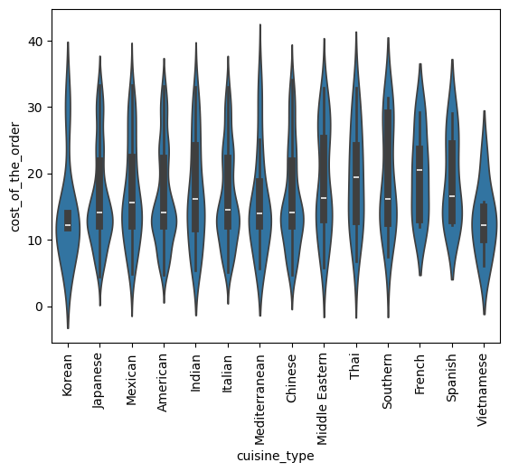

```python
# Next we'll compare catagorical data with numeric data
sns.violinplot(data=data, x='cuisine_type', y='cost_of_the_order')
plt.xticks(rotation=90)
plt.show()
```

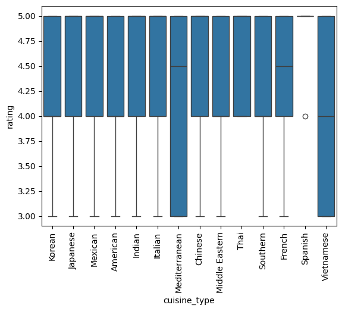

```python
# comparing cuisine type and rating
sns.boxplot(data=data, x='cuisine_type', y='rating')
plt.xticks(rotation=90)
plt.show()
```

- The most useful information we can get from this plot is that Spanish food is rated very highly.

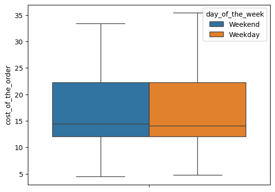

```python
#let's examine how weekday/weekend affects cuisine_type, delivery time, prep time, and cost of the order
sns.boxplot(data=data, y='cost_of_the_order',hue='day_of_the_week')
plt.xticks(rotation=90)
plt.show()
```

- The costs of the order is the same weekdays and weekends.

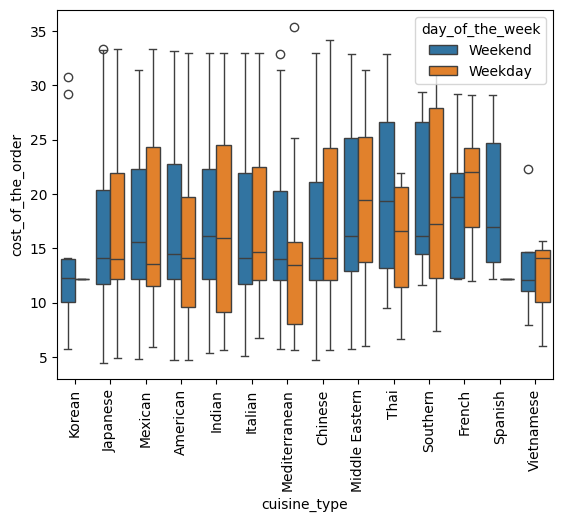

```python
sns.boxplot(data=data, x="cuisine_type", y='cost_of_the_order',hue='day_of_the_week')
plt.xticks(rotation=90)
plt.show()
```

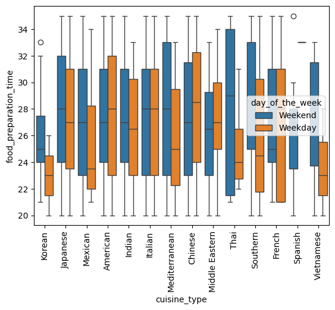

```python
sns.boxplot(data=data, x='cuisine_type', y='food_preparation_time',hue='day_of_the_week')
plt.xticks(rotation=90)
plt.show()
```

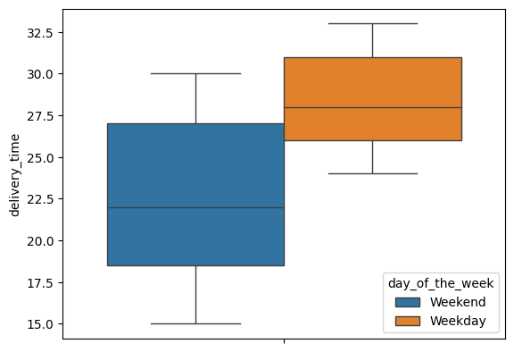

```python
sns.boxplot(data=data, y='delivery_time',hue='day_of_the_week')
plt.xticks(rotation=90)
plt.show()
```

- Most likely delivery times are shorter on weekends because more delivery personnel are available. This is despite the fact that more than 2/3 of deliveries occured on the weekend.

**I would have done a greater variety of plots but there wasn't any strongly correlated data**